# Q2_python

```python
import numpy as np
import matplotlib.pyplot as plt
```

```python
def generate_B():#B = AtA
    temp = (np.random.normal(0, 1, size=(3,10)))# random matrix A that is the factor of the matrix B.
    B = (np.matmul(np.transpose(temp),temp))
    return B
```

```python
def generate_A():#any matrix A.
    A = (np.random.rand(3,10))
    return A
```

```python
def compute_L(B,A):#compute L that gives the Loss function for the given matrix B. L = sum(sum([B-AtA]**2))
    M = np.matmul(np.transpose(A),A)
    temp2 = np.subtract(B,M)
    temp3 = np.matmul(temp2,temp2)
    L = np.sum(temp3)
    return L
```

```python
def compute_Anew(A,G,alpha):#A_new = A - alpha*G
    return np.subtract(A,np.dot(alpha, G))
```

```python
def compute_G(B,A):# G(A) = 4At(AtA - B)
    At = np.transpose(A)
    AtA = np.matmul(At,A)
    temp2 = np.subtract(AtA,B)
    return np.dot(4, np.matmul(A,temp2))
```

```python
B = generate_B()
print("B:")
print(B)
```

```
B:
[[ 1.8162422  -1.4463971   1.98845083 -2.33897073  1.9209928   2.30401174
   2.57023537 -0.08547523 -0.59546789 -0.80803774]
 [-1.4463971   3.65584253 -1.64512134  2.26007432 -2.67695963 -2.65891616
  -4.24358877 -1.87786812  0.31039572 -0.3555158 ]
 [ 1.98845083 -1.64512134  3.98365657 -0.76057775  1.77989489  0.47244551
   3.71967053 -1.51847802 -0.54018998 -1.26996547]
 [-2.33897073  2.26007432 -0.76057775  4.88994702 -3.0083089  -5.17368533
  -2.80463458 -1.67541324  0.84884408  0.47108078]
 [ 1.9209928  -2.67695963  1.77989489 -3.0083089   2.62574812  3.21749753
   3.55903606  1.08781943 -0.57573268 -0.31716445]
 [ 2.30401174 -2.65891616  0.47244551 -5.17368533  3.21749753  5.56835376
   3.00665047  2.22106112 -0.82500259 -0.2261783 ]
 [ 2.57023537 -4.24358877  3.71967053 -2.80463458  3.55903606  3.00665047
   5.96628723  0.89133114 -0.64813528 -0.46044622]
 [-0.08547523 -1.87786812 -1.51847802 -1.67541324  1.08781943  2.22106112
   0.89133114  2.71785195  0.0674557   1.14880515]
 [-0.59546789  0.31039572 -0.54018998  0.84884408 -0.57573268 -0.82500259
  -0.64813528  0.0674557   0.21237227  0.30582182]
 [-0.80803774 -0.3555158  -1.26996547  0.47108078 -0.31716445 -0.2261783
  -0.46044622  1.14880515  0.30582182  0.85113623]]
```

```python
A = generate_A()
A_original = A
print(A)
```

```
[[0.62519191 0.62976639 0.19617421 0.39356727 0.45845524 0.52085481
  0.79862668 0.19980013 0.27921599 0.00805149]
 [0.81626577 0.42130495 0.39559157 0.14245148 0.09042754 0.6921108
  0.5323526  0.02256219 0.50005347 0.45408585]
 [0.59189588 0.68798624 0.67496398 0.7288441  0.96032847 0.83225333
  0.20161884 0.38544507 0.47421838 0.45651747]]
```

```python
LossArray = []
for i in range(0,5000):
    L = compute_L(B,A)
    G = compute_G(B,A)
    alpha = 0.002
    A= compute_Anew(A,G,alpha)
    LossArray.append(L)

print("LossArray", LossArray[4990:])
```

```
LossArray [9.48258571138277e-28, 9.48258571138277e-28, 9.48258571138277e-28, 9.48258571138277e-28, 9.48258571138277e-28, 9.48258571138277e-28, 9.48258571138277e-28, 9.48258571138277e-28, 9.48258571138277e-28, 9.48258571138277e-28]
```

Plotting the Loss function

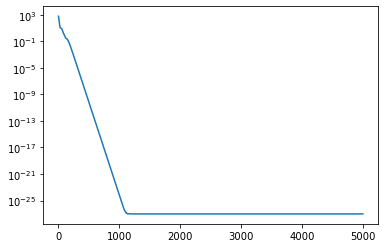

```python
plt.yscale("log")
plt.plot(LossArray)
plt.show()
```

- The L(loss) is huge initially and has a drastic decrease where it moves towards 0 but never really becomes 0.

```python
def compute_Bnew(A):
     return (np.matmul(np.transpose(A),A))
```

```python
Bnew = (compute_Bnew(A))
print(Bnew)
print()
print(np.subtract(B,Bnew))
```

```
[[ 1.8162422  -1.4463971   1.98845083 -2.33897073  1.9209928   2.30401174
   2.57023537 -0.08547523 -0.59546789 -0.80803774]
 [-1.4463971   3.65584253 -1.64512134  2.26007432 -2.67695963 -2.65891616
  -4.24358877 -1.87786812  0.31039572 -0.3555158 ]
 [ 1.98845083 -1.64512134  3.98365657 -0.76057775  1.77989489  0.47244551
   3.71967053 -1.51847802 -0.54018998 -1.26996547]
 [-2.33897073  2.26007432 -0.76057775  4.88994702 -3.0083089  -5.17368533
  -2.80463458 -1.67541324  0.84884408  0.47108078]
 [ 1.9209928  -2.67695963  1.77989489 -3.0083089   2.62574812  3.21749753
   3.55903606  1.08781943 -0.57573268 -0.31716445]
 [ 2.30401174 -2.65891616  0.47244551 -5.17368533  3.21749753  5.56835376
   3.00665047  2.22106112 -0.82500259 -0.2261783 ]
 [ 2.57023537 -4.24358877  3.71967053 -2.80463458  3.55903606  3.00665047
   5.96628723  0.89133114 -0.64813528 -0.46044622]
 [-0.08547523 -1.87786812 -1.51847802 -1.67541324  1.08781943  2.22106112
   0.89133114  2.71785195  0.0674557   1.14880515]
 [-0.59546789  0.31039572 -0.54018998  0.84884408 -0.57573268 -0.82500259
  -0.64813528  0.0674557   0.21237227  0.30582182]
 [-0.80803774 -0.3555158  -1.26996547  0.47108078 -0.31716445 -0.2261783
  -0.46044622  1.14880515  0.30582182  0.85113623]]

[[-2.44249065e-15  1.11022302e-15 -4.44089210e-16  3.10862447e-15
   1.33226763e-15  1.77635684e-15 -3.10862447e-15  2.52575738e-15
   7.77156117e-16  1.44328993e-15]
 [ 1.11022302e-15  5.77315973e-15 -2.22044605e-16  2.22044605e-15
   2.22044605e-15  3.55271368e-15 -4.44089210e-15  6.66133815e-16
  -3.33066907e-16 -4.44089210e-16]
 [-4.44089210e-16 -2.22044605e-16  4.88498131e-15 -6.66133815e-16
   1.77635684e-15 -9.43689571e-16  0.00000000e+00 -6.66133815e-16
  -1.11022302e-16 -4.44089210e-16]
 [ 3.10862447e-15  2.22044605e-15 -6.66133815e-16 -1.15463195e-14
  -2.22044605e-15  0.00000000e+00 -1.77635684e-15 -2.44249065e-15
  -1.77635684e-15 -2.66453526e-15]
 [ 1.33226763e-15  2.22044605e-15  1.77635684e-15 -2.22044605e-15
   8.88178420e-16  3.55271368e-15 -1.77635684e-15 -2.44249065e-15
  -9.99200722e-16 -2.55351296e-15]
 [ 1.77635684e-15  3.55271368e-15 -9.43689571e-16  0.00000000e+00
   3.55271368e-15  8.88178420e-15 -2.66453526e-15 -1.77635684e-15
  -9.99200722e-16 -2.49800181e-15]
 [-3.10862447e-15 -4.44089210e-15  0.00000000e+00 -1.77635684e-15
  -1.77635684e-15 -2.66453526e-15  8.88178420e-16  1.11022302e-15
   7.77156117e-16  1.60982339e-15]
 [ 2.52575738e-15  6.66133815e-16 -6.66133815e-16 -2.44249065e-15
  -2.44249065e-15 -1.77635684e-15  1.11022302e-15 -5.77315973e-15
  -8.60422844e-16 -3.33066907e-15]
 [ 7.77156117e-16 -3.33066907e-16 -1.11022302e-16 -1.77635684e-15
  -9.99200722e-16 -9.99200722e-16  7.77156117e-16 -8.60422844e-16
  -2.77555756e-16 -4.99600361e-16]
 [ 1.44328993e-15 -4.44089210e-16 -4.44089210e-16 -2.66453526e-15
  -2.55351296e-15 -2.49800181e-15  1.60982339e-15 -3.33066907e-15
  -4.99600361e-16 -1.99840144e-15]]
```

Finding if we get the same A back even though we start with different A.

```python
print(A_original)
```

```
[[0.62519191 0.62976639 0.19617421 0.39356727 0.45845524 0.52085481
  0.79862668 0.19980013 0.27921599 0.00805149]
 [0.81626577 0.42130495 0.39559157 0.14245148 0.09042754 0.6921108
  0.5323526  0.02256219 0.50005347 0.45408585]
 [0.59189588 0.68798624 0.67496398 0.7288441  0.96032847 0.83225333
  0.20161884 0.38544507 0.47421838 0.45651747]]
```

```python
for i in range(10):
    A = generate_A()
    for i in range(0,5000):
        L = compute_L(B,A)
        G = compute_G(B,A)
        alpha = 0.002
        A= compute_Anew(A,G,alpha)
    print()
    print(np.subtract(A_original,A))
```

```
[[-0.18951536  1.58269977  0.33538291  2.53241512 -0.7447854  -1.80393583
  -0.13105382 -0.84559609  0.58840001  0.01333705]
 [ 0.3262799   2.07253807 -0.82005518  0.32368292 -0.87933039  0.39891648
  -1.57316876 -0.40553607  0.53952407  0.3161473 ]
 [-0.36330468  0.54241939 -0.90189381  1.26028744  0.47295834  0.55343563
  -0.61615937  1.58616592  0.81365849  1.36870235]]

[[ 0.22545558  2.37407984 -0.70130105  0.7087671  -0.53491597  0.03162336
  -1.21847626 -0.54301734  0.29163709 -0.28658021]
 [ 0.70181021  0.99484122  1.53293131  1.64429414 -0.49976314 -1.07354768
   0.54852538 -1.38675852  0.58206643  0.02315513]
 [-0.69003742  1.22115534 -0.69786269  2.32103275 -0.17573346 -0.65484332
  -1.17581406  0.80957865  0.92753049  1.2171929 ]]

[[ 3.08128529e-01  1.83811118e+00 -1.19748571e+00 -7.21557474e-02
  -1.15618012e-01  9.77351138e-01 -9.71308761e-01  3.06544989e-01
   2.59592635e-01  4.87916882e-05]
 [-3.79381090e-01  6.56016212e-01 -1.01073969e+00  1.45308191e+00
  -8.23104736e-01 -4.56668012e-01 -5.84466601e-01  7.30194025e-01
   9.32133272e-01  1.29837361e+00]
 [ 5.69738255e-02  2.15108432e+00  9.27156331e-01  2.44794182e+00
  -2.48657384e-01 -1.17778948e+00 -1.05787734e+00 -1.09971979e+00
   6.33260007e-01  8.46971376e-02]]

[[ 0.69405298  1.51479965 -0.83026061 -0.62751887  0.31072366  1.53603908
  -0.43743117  0.34622697  0.13078708 -0.15263046]
 [-0.08254326  0.22230733 -1.19756611  0.52146565 -0.31816006  0.57737455
  -0.23506606  1.29109165  0.81689392  1.36234969]
 [-0.4099238   2.37112575  0.04891547  2.65333842 -0.60075438 -1.29485509
  -1.76039971 -0.65726492  0.77414048  0.43716995]]

[[-0.30536206  1.73239377 -1.75360204  0.72478154 -0.51188405  0.27893244
  -1.27050149  0.71491335  0.50563117  0.48717147]
 [ 0.63458369 -0.97340387 -0.01838086 -0.1214801   0.65274939  1.2583333
   1.5064206   1.43378617  0.64523854  1.20651649]
 [-0.36586355  1.3914368   0.57173616  2.89923214 -0.20927997 -1.44573249
  -0.65639477 -0.2934932   0.84842385  0.69194985]]

[[ 0.1974364   2.09691259  0.54185745  1.96714644 -0.67392352 -1.35784393
  -0.39784685 -1.34222439  0.39598297 -0.44219825]
```

[output cut: 17 more lines]

```
  -1.09290919  0.9006844   0.39715698  0.5338453 ]]

[[ 1.20562415  1.47344083  0.30875097 -0.63873616  0.56963866  1.39023921
   0.24278817 -0.44198821 -0.0258016  -0.65976348]
 [-0.19965989  2.10304942 -0.25822128  2.07044241 -1.47733007 -1.43424899
  -1.44450863 -0.99936425  0.80467281  0.44892057]
 [-0.07686093  1.02826775 -1.20745781  0.40150998  0.56596513  1.3718074
  -1.12101127  1.50866635  0.63714045  1.09301784]]

[[-0.66401036  1.77114537 -1.59726127  1.69183503 -0.88382514 -0.717456
  -1.30530251  0.48068935  0.67176179  0.62194642]
 [ 0.43174573  0.66966024  1.26281013  1.91864008 -0.54028648 -1.25240426
   0.64609423 -0.96420321  0.70668514  0.35606515]
 [ 0.6715454   2.20172868  0.79816189  0.95155897  0.30746454  0.32846643
  -1.03403162 -0.90499952  0.34938481 -0.22514314]]
```

- We do no recover the same matrix A everytime we start with a different initial matrix.

Checking if we could recover the same k dimension

```python
def generate_B_k(k):#B = AtA
    temp = (np.random.normal(0, 1, size=(k,10)))# random matrix A that is the factor of the matrix B.
    B = (np.matmul(temp.transpose(),temp))
    return B

def generate_A_k(k):#any matrix A.
    A = (np.random.rand(k,10))
    return A
```

```python
A_original = generate_A_k(5)
```

```
A:
LossArray k=3
[0.0004291820390703303, 0.0004290119466085381, 0.00042884195524778496, 0.00042867206490798096, 0.0004285022755090767, 0.0004283325869710548, 0.00042816299921410794, 0.0004279935121584274, 0.0004278241257243087, 0.00042765483983208747]

[[-2.52040749e-01 -1.23426389e+00  7.02968315e-01 -9.19924526e-01
   8.71491156e-01 -2.74460615e-01  1.01381662e+00  1.49370770e-01
   7.37962906e-01  1.29152094e+00]
 [ 1.46328327e+00 -1.32598413e+00  2.46257295e-01  9.40917165e-01
   1.51702793e+00  2.55495123e-01  1.10524588e-02 -1.35583494e-01
  -5.17990147e-01 -2.08206578e-01]
 [-3.05259026e-02 -2.33638569e-01  2.64713354e-01  3.93300539e-01
  -1.56364187e-01 -1.50767463e-01  1.10256980e-01 -1.01783714e-01
   1.03881800e+00 -4.31018161e-03]
 [-5.21488146e-01  5.46777150e-01 -1.90500674e-03  4.40246939e-01
  -1.21527837e+00 -2.10802916e-01 -2.49441565e-02 -4.82153028e-02
   1.60678018e+00 -3.08573202e-01]
 [ 4.55947276e-01 -8.41758181e-01  5.28885303e-01  1.14206247e+00
  -6.76657686e-02 -2.68425911e-01  2.35181901e-01 -1.76020795e-01
   2.10437035e+00 -3.65080510e-01]]
```

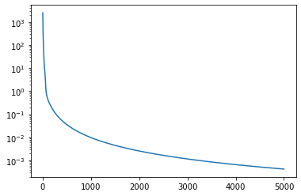

```python
B = generate_B_k(3)
# print("B:")
# print(B)
# print()
print("A:")
A = A_original

LossArray = []
for i in range(0,5000):
    L = compute_L(B,A)
    G = compute_G(B,A)
    alpha = 0.002
    A= compute_Anew(A,G,alpha)
    LossArray.append(L)

print("LossArray k=3")
print(LossArray[4990:])
print()
print(A)


plt.yscale("log")
plt.plot(LossArray)
plt.show()
```

```
LossArray k=4
[1.4464184178300082e-05, 1.4458494900742599e-05, 1.4452808979398749e-05, 1.4447126411603521e-05, 1.444144719473325e-05, 1.4435771326142398e-05, 1.4430098803216143e-05, 1.4424429623308764e-05, 1.4418763783799522e-05, 1.4413101282077718e-05]

[[ 0.25364837 -0.02579514  1.10647679 -0.44652713  0.19794991  1.36340584
   0.99580036  0.24446843  0.36612723  0.31253937]
 [ 0.20092588 -0.20721753 -0.39484313  0.76835464  0.45665558  0.25073716
   0.21707915  0.52943372  0.50126619  0.85871016]
 [-1.44784096 -0.41471299  0.89506561  1.70792289  0.33353825  0.6718405
   0.78659358  0.19981945 -0.30924515 -0.11641572]
 [ 1.60415689  1.36773162 -1.08659523 -0.16213657  0.53240212  0.0298967
  -0.32206418 -0.12959102  0.64042277  1.12507326]
 [ 0.35636996  1.42547539  2.08983319 -1.23074002 -0.21711452  1.50815375
   1.07231104 -1.14972197 -0.57116638 -1.16017994]]
```

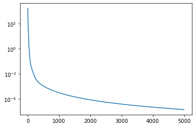

```python
B = generate_B_k(4)
# print("B:")
# print(B)
# print()
# print("A:")
A = A_original

LossArray = []
for i in range(0,5000):
    L = compute_L(B,A)
    G = compute_G(B,A)
    alpha = 0.002
    A= compute_Anew(A,G,alpha)
    LossArray.append(L)

print("LossArray k=4")
print(LossArray[4990:])
print()
print(A)


plt.yscale("log")
plt.plot(LossArray)
plt.show()
```

```
LossArray k=5
[1.481214231300757e-27, 1.481214231300757e-27, 1.481214231300757e-27, 1.481214231300757e-27, 1.481214231300757e-27, 1.481214231300757e-27, 1.481214231300757e-27, 1.481214231300757e-27, 1.481214231300757e-27, 1.481214231300757e-27]
```

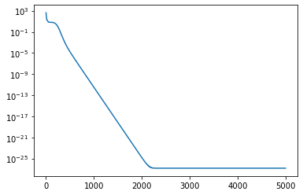

```python
B = generate_B_k(5)
# print("B:")
# print(B)
# print()
# print("A:")
# A = A_original

LossArray = []
for i in range(0,5000):
    L = compute_L(B,A)
    G = compute_G(B,A)
    alpha = 0.002
    A= compute_Anew(A,G,alpha)
    LossArray.append(L)

print("LossArray k=5")
print(LossArray[4990:])

plt.yscale("log")
plt.plot(LossArray)
plt.show()
```

```
LossArray k=6
[0.6731965807648794, 0.6731965807648799, 0.6731965807648794, 0.6731965807648799, 0.6731965807648794, 0.6731965807648799, 0.6731965807648794, 0.6731965807648799, 0.6731965807648794, 0.6731965807648799]

[[ 8.38490321e-01  6.67977725e-01 -3.04843827e-01 -1.50567873e+00
   2.19960632e+00  6.29252976e-01  1.46050662e+00 -1.20799220e+00
  -1.06635720e+00  5.11160008e-01]
 [ 1.90734474e+00  2.88198365e-01  2.70789888e-01 -6.30684288e-01
   6.38523450e-01  1.15571939e+00 -8.80248699e-01 -5.39638634e-01
   5.04429030e-01  4.50544271e-01]
 [-2.40572544e-01  1.13472286e+00 -2.91633168e-02  2.39241958e-01
   2.14051106e+00  1.72200059e-01  2.01894875e-02 -1.64198008e+00
   9.35680542e-02  1.85955790e+00]
 [ 2.97156585e-01  3.56658943e-01 -2.57281545e-01  1.16182203e+00
   4.81242787e-01  1.33989350e+00  3.02292198e-01 -1.91388631e-02
  -5.12688485e-01  5.36572097e-01]
 [ 5.97305949e-02 -1.02045963e+00  2.66789723e+00  2.88961410e-01
  -2.22344124e-01 -2.41226185e-04  9.53980227e-01  5.79556610e-01
  -3.90121476e-01  1.09895324e+00]]
```

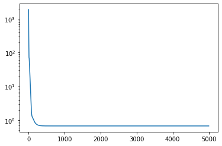

```python
B = generate_B_k(6)
# print("B:")
# print(B)
# print()
# print("A:")
A = A_original

LossArray = []
for i in range(0,5000):
    L = compute_L(B,A)
    G = compute_G(B,A)
    alpha = 0.002
    A= compute_Anew(A,G,alpha)
    LossArray.append(L)

print("LossArray k=6")
print(LossArray[4990:])
print()
print(A)

plt.yscale("log")
plt.plot(LossArray)
plt.show()
```

```
A:
LossArray k=7
[6.103826481024858, 6.103826481024859, 6.103826481024858, 6.103826481024859, 6.103826481024858, 6.103826481024859, 6.103826481024859, 6.103826481024858, 6.103826481024859, 6.103826481024858]

[[-1.73244794  0.33701303 -0.73626432 -0.28573312  1.08573486  1.47610764
   1.53096707  0.24302993  1.65178365 -0.2216771 ]
 [-0.32841032 -1.0347866   0.16940298  1.43407685 -0.70643778 -0.33775113
   1.11725457  1.49623314 -0.16468783 -0.00245642]
 [-0.44700366  1.32814047  0.88452461  0.31434687  0.41457587  1.86608112
   1.03527775 -1.08290941 -1.96270213 -1.52436943]
 [ 0.68542325  0.54789519  0.00441826  1.23972814 -0.94651516  1.31251214
  -0.50561702  0.81248679  1.12433129 -0.58682434]
 [ 1.47247747  0.29501667  0.02901022  0.75008867  0.95874109 -2.34981059
   1.20391195  1.53604925  0.75075528 -1.78877734]]
```

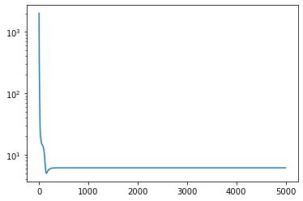

```python
B = generate_B_k(7)
# print("B:")
# print(B)
# print()
print("A:")
A = A_original

LossArray = []
for i in range(0,5000):
    L = compute_L(B,A)
    G = compute_G(B,A)
    alpha = 0.002
    A= compute_Anew(A,G,alpha)
    LossArray.append(L)

print("LossArray k=7")
print(LossArray[4990:])
print()
print(A)


plt.yscale("log")
plt.plot(LossArray)
plt.show()
```

```
A:
LossArray k=8
[3.6040051152919697, 3.6040051152919697, 3.6040051152919697, 3.6040051152919697, 3.6040051152919697, 3.6040051152919697, 3.6040051152919697, 3.6040051152919697, 3.6040051152919697, 3.6040051152919697]

[[-0.68888379 -0.14246954 -1.02951385  0.18557719  2.19498806  1.21718794
   0.64274021  1.29352292 -0.39348353 -1.69058862]
 [ 0.79130168  0.97846329 -1.30148431  1.2977699  -0.45567987  0.66101685
   1.20827364 -0.4605443   1.12018816  0.06571232]
 [-0.18059006  0.3848597   1.18843486  2.28285555  0.1245872  -0.32392651
  -2.02517437 -0.80840703 -0.05370376  0.34702266]
 [ 0.9629721   1.63432306 -2.54738316  1.26219298 -0.85763174 -1.10660049
  -0.51303774  1.12627457  1.19747036  0.47040606]
 [ 1.39050739 -0.18733577  0.71595687  0.57810211  0.46356189 -0.35256424
   1.48846852  0.39952998  1.27616401 -0.2106892 ]]
```

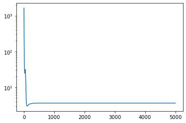

```python
B = generate_B_k(8)
# print("B:")
# print(B)
# print()
print("A:")
A = A_original

LossArray = []
for i in range(0,5000):
    L = compute_L(B,A)
    G = compute_G(B,A)
    alpha = 0.002
    A= compute_Anew(A,G,alpha)
    LossArray.append(L)

print("LossArray k=8")
print(LossArray[4990:])
print()
print(A)


plt.yscale("log")
plt.plot(LossArray)
plt.show()
```

```
A:
LossArray k=9
[8.246087439473374, 8.246087439473374, 8.246087439473374, 8.246087439473374, 8.246087439473374, 8.246087439473374, 8.246087439473374, 8.246087439473374, 8.246087439473374, 8.246087439473374]

[[ 5.94049112e-01 -2.65641418e-01  2.28076142e+00 -2.12638080e-01
   3.93571640e-01  2.83534690e+00 -7.22501306e-01  1.51734980e+00
  -1.76842620e+00 -8.53976052e-02]
 [ 1.28980479e+00 -1.16379191e+00  8.50029894e-01  1.94810379e+00
   4.59562033e-01  4.67772638e-01 -6.97738199e-02 -1.29469827e+00
   7.33664320e-01  1.74181748e-01]
 [ 9.14202399e-02 -2.34392054e-02  1.54931091e+00  8.05405537e-01
   9.30936239e-01 -8.91131884e-01  1.19297191e+00 -5.26864725e-01
   1.51206194e+00  1.56848859e+00]
 [ 4.83026765e-01  1.22748180e+00  8.87407223e-01 -6.32113422e-02
  -1.83037743e+00  3.72379231e-01 -4.60466418e-01  1.37951264e+00
   1.85542228e+00  5.89616744e-01]
 [ 1.06213951e+00  1.16797218e+00  2.10571375e+00  1.10266344e+00
   1.97682930e-01 -2.26642946e+00  5.94676139e-02  1.60787842e+00
  -5.11649041e-01  2.52872019e-03]]
```

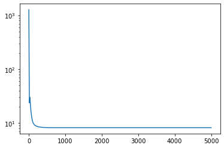

```python
B = generate_B_k(9)
# print("B:")
# print(B)
# print()
print("A:")
A = A_original

LossArray = []
for i in range(0,5000):
    L = compute_L(B,A)
    G = compute_G(B,A)
    alpha = 0.002
    A= compute_Anew(A,G,alpha)
    LossArray.append(L)

print("LossArray k=9")
print(LossArray[4990:])
print()
print(A)


plt.yscale("log")
plt.plot(LossArray)
plt.show()
```

*Inferences*

- Suppose columns of matrix A are vectors[a1,a2,...,ad] then A^tA is a matrix whose elements contain the cross product of each of the row vectors of matrix A. It gives the relation between the row vectors of matrix A , their magnitude and their cosines as well.
- Thus when we tried to start from different initial matrix A and converge to one A, it wasnt possible because the magnitude were totally different and angles between the row vectors of matrix A as well.
- Same goes for a the different k x D matrix we generated in the previous example.
- In all these cases we are trying to optimize a value A^tA and not the matrix A. There could be multiple matrices A with different k as dimension (k x D), that give the same A^tA. It is possible because it is just the different combination of mulitple dot products of row vectors of matrix A.

When B is a DxD identity matrix, then

```
[[1. 0. 0. 0. 0. 0. 0. 0. 0. 0.]
 [0. 1. 0. 0. 0. 0. 0. 0. 0. 0.]
 [0. 0. 1. 0. 0. 0. 0. 0. 0. 0.]
 [0. 0. 0. 1. 0. 0. 0. 0. 0. 0.]
 [0. 0. 0. 0. 1. 0. 0. 0. 0. 0.]
 [0. 0. 0. 0. 0. 1. 0. 0. 0. 0.]
 [0. 0. 0. 0. 0. 0. 1. 0. 0. 0.]
 [0. 0. 0. 0. 0. 0. 0. 1. 0. 0.]
 [0. 0. 0. 0. 0. 0. 0. 0. 1. 0.]
 [0. 0. 0. 0. 0. 0. 0. 0. 0. 1.]]

[[0.95871398 0.53746554 0.59440675 0.7862882  0.27145968 0.68333248
  0.54352117 0.87346944 0.86080249 0.61046869]
 [0.3198026  0.70387859 0.00357496 0.32753892 0.72320081 0.8589318
  0.10160179 0.96280666 0.53775246 0.89232231]
 [0.83179118 0.3553495  0.69568086 0.47966341 0.54526509 0.98560783
  0.5292085  0.28918526 0.08655123 0.85754534]
 [0.46835089 0.85004991 0.86306713 0.85089875 0.09212971 0.81812283
  0.77999357 0.58274299 0.32415778 0.12970601]
 [0.31663428 0.50768755 0.74764235 0.7397268  0.04178667 0.26408435
  0.17830048 0.37891081 0.46722041 0.8638131 ]
 [0.46449329 0.42332882 0.32565823 0.12849442 0.64069724 0.96603315
  0.90597736 0.03960774 0.44915441 0.77531496]
 [0.04355059 0.98963608 0.42595045 0.14411021 0.28623325 0.60236673
  0.71867015 0.99273502 0.7297421  0.72558516]
 [0.29041495 0.57656019 0.2867268  0.47681518 0.22590747 0.81561495
  0.9682165  0.36568512 0.94089261 0.49267396]
 [0.43092466 0.56934505 0.17287095 0.67575246 0.54639129 0.64783887
  0.09557403 0.20750217 0.85911616 0.84629561]
 [0.27380715 0.83606975 0.99311173 0.74090449 0.95986326 0.93296652
  0.77480476 0.13092523 0.29387181 0.69469763]]

LossArray
[1.6899421973681329e-28, 1.6899421973681329e-28, 1.6899421973681329e-28, 1.6899421973681329e-28, 1.6899421973681329e-28, 1.6899421973681329e-28, 1.6899421973681329e-28, 1.6899421973681329e-28, 1.6899421973681329e-28, 1.6899421973681329e-28]
```

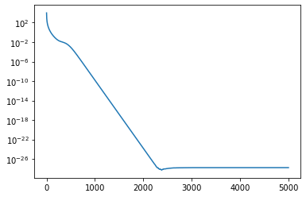

```python
B = np.identity(10)
print(B)
print()
A = generate_A_k(10)
print(A)
print()
LossArray = []
for i in range(0,5000):
    L = compute_L(B,A)
    LossArray.append(L)
    G = compute_G(B,A)
    alpha = 0.002
    A = compute_Anew(A,G,alpha)

print("LossArray")
print(LossArray[4990:])

plt.yscale("log")
plt.plot(LossArray)
plt.show()
```

```python
# print()
# print(A)
# print()
AtA = (np.matmul(np.transpose(A),A))
print(AtA)
# print(np.subtract(B,AtA))
```

```
[[ 1.00000000e+00 -7.49400542e-16  1.33226763e-15 -1.83186799e-15
  -6.93889390e-16  4.44089210e-16 -1.98452366e-15 -2.49800181e-16
   6.93889390e-16 -5.75928194e-16]
 [-7.49400542e-16  1.00000000e+00  8.39606162e-16 -3.05311332e-16
  -7.70217223e-16  2.06779038e-15 -6.24500451e-16  1.53869972e-15
   1.27675648e-15  8.32667268e-17]
 [ 1.33226763e-15  8.39606162e-16  1.00000000e+00  1.48492330e-15
  -2.22044605e-16 -7.18175519e-16  1.92207361e-15  5.27355937e-16
  -6.73072709e-16  1.77635684e-15]
 [-1.83186799e-15 -3.05311332e-16  1.48492330e-15  1.00000000e+00
  -1.66533454e-16  2.12330153e-15 -7.07767178e-16 -2.77555756e-17
   1.37390099e-15 -1.08246745e-15]
 [-6.93889390e-16 -7.70217223e-16 -2.22044605e-16 -1.66533454e-16
   1.00000000e+00  2.08166817e-16 -3.88578059e-16 -6.38378239e-16
   3.33066907e-16 -1.05471187e-15]
 [ 4.44089210e-16  2.06779038e-15 -7.18175519e-16  2.12330153e-15
   2.08166817e-16  1.00000000e+00 -6.10622664e-16  9.15933995e-16
  -9.85322934e-16  1.06858966e-15]
 [-1.98452366e-15 -6.24500451e-16  1.92207361e-15 -7.07767178e-16
  -3.88578059e-16 -6.10622664e-16  1.00000000e+00 -8.32667268e-16
   3.88578059e-16 -5.27355937e-16]
 [-2.49800181e-16  1.53869972e-15  5.27355937e-16 -2.77555756e-17
  -6.38378239e-16  9.15933995e-16 -8.32667268e-16  1.00000000e+00
   1.05471187e-15 -4.44089210e-16]
 [ 6.93889390e-16  1.27675648e-15 -6.73072709e-16  1.37390099e-15
   3.33066907e-16 -9.85322934e-16  3.88578059e-16  1.05471187e-15
   1.00000000e+00 -6.93889390e-16]
 [-5.75928194e-16  8.32667268e-17  1.77635684e-15 -1.08246745e-15
  -1.05471187e-15  1.06858966e-15 -5.27355937e-16 -4.44089210e-16
  -6.93889390e-16  1.00000000e+00]]
```

- we are able to recover the identity matrix using the new A again with all the other elements being insignificantly small.

```
[[ 1.  0.  0.  0.  0.  0.  0.  0.  0.  0.]
 [ 0.  1.  0.  0.  0.  0.  0.  0.  0.  0.]
 [ 0.  0.  1.  0.  0.  0.  0.  0.  0.  0.]
 [ 0.  0.  0.  1.  0.  0.  0.  0.  0.  0.]
 [ 0.  0.  0.  0.  1.  0.  0.  0.  0.  0.]
 [ 0.  0.  0.  0.  0.  1.  0.  0.  0.  0.]
 [ 0.  0.  0.  0.  0.  0.  1.  0.  0.  0.]
 [ 0.  0.  0.  0.  0.  0.  0.  1.  0.  0.]
 [ 0.  0.  0.  0.  0.  0.  0.  0.  1.  0.]
 [ 0.  0.  0.  0.  0.  0.  0.  0.  0. -1.]]

[[0.93709688 0.15700881 0.01708156 0.55557934 0.12767054 0.59106766
  0.31492775 0.13915907 0.4070651  0.8855333 ]
 [0.95734969 0.55509071 0.45787366 0.16137062 0.11364086 0.27773085
  0.45788958 0.11730549 0.61330905 0.53115441]
 [0.72932804 0.22948157 0.99102802 0.38697307 0.11789477 0.6309398
  0.36582773 0.2476357  0.8551105  0.21879843]
 [0.54008748 0.06384461 0.02428871 0.59741369 0.92383464 0.3618687
  0.0318249  0.94960385 0.36930617 0.14513618]
 [0.95489441 0.94445175 0.03323544 0.79611206 0.27584713 0.87399975
  0.34581989 0.22534393 0.40379566 0.13634973]
 [0.09310377 0.09286422 0.83895505 0.31044521 0.61512793 0.65389078
  0.47256999 0.20448171 0.52177457 0.40893432]
 [0.43570579 0.04994289 0.13925919 0.68159277 0.63168918 0.52253069
  0.6210753  0.43557669 0.19568452 0.53698553]
 [0.06720536 0.22493617 0.02190552 0.26695639 0.51976271 0.3295213
  0.2432488  0.09327767 0.16356577 0.95415292]
 [0.75520364 0.17629617 0.15411829 0.11142658 0.51434041 0.11351878
  0.31963614 0.2984014  0.70815818 0.87011491]
 [0.75251429 0.3873228  0.226604   0.4857812  0.17963013 0.10409561
  0.57474135 0.17184965 0.10541157 0.86634657]]

LossArray
[1.0, 1.0, 1.0, 1.0, 1.0, 1.0, 1.0, 1.0, 1.0, 1.0]
```

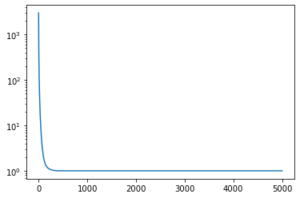

```python
B = np.identity(10)
B[-1][-1] = -1
print(B)
print()
A = generate_A_k(10)
print(A)
print()
LossArray = []
for i in range(0,5000):
    L = compute_L(B,A)
    G = compute_G(B,A)
    alpha = 0.002
    A= compute_Anew(A,G,alpha)
    LossArray.append(L)

print("LossArray")
print(LossArray[4990:])

plt.yscale("log")
plt.plot(LossArray)
plt.show()
```

```python
AtA = (np.matmul(np.transpose(A),A))
print(AtA)
```

```
[[ 1.00000000e+00  1.25593980e-15 -6.93889390e-16  6.93889390e-16
   2.42861287e-16  4.16333634e-16  3.33066907e-16  1.66533454e-15
   0.00000000e+00  1.80555932e-34]
 [ 1.25593980e-15  1.00000000e+00  3.53883589e-16 -5.96744876e-16
  -2.49800181e-16  1.05471187e-15 -5.55111512e-16 -6.93889390e-16
   1.17961196e-16  4.81482486e-35]
 [-6.93889390e-16  3.53883589e-16  1.00000000e+00 -3.88578059e-16
  -1.40859546e-15  1.38777878e-17 -5.55111512e-17  1.40165657e-15
  -2.77555756e-17 -9.62964972e-35]
 [ 6.93889390e-16 -5.96744876e-16 -3.88578059e-16  1.00000000e+00
   5.68989300e-16  1.33226763e-15  8.32667268e-16  1.85962357e-15
   2.77555756e-17 -2.40741243e-35]
 [ 2.42861287e-16 -2.49800181e-16 -1.40859546e-15  5.68989300e-16
   1.00000000e+00 -8.60422844e-16 -8.18789481e-16  1.62370117e-15
  -3.26128013e-16 -2.64815367e-34]
 [ 4.16333634e-16  1.05471187e-15  1.38777878e-17  1.33226763e-15
  -8.60422844e-16  1.00000000e+00 -6.59194921e-16  6.93889390e-17
   2.77555756e-16 -1.32407684e-34]
 [ 3.33066907e-16 -5.55111512e-16 -5.55111512e-17  8.32667268e-16
  -8.18789481e-16 -6.59194921e-16  1.00000000e+00 -1.94289029e-15
  -1.56125113e-16 -4.81482486e-35]
 [ 1.66533454e-15 -6.93889390e-16  1.40165657e-15  1.85962357e-15
   1.62370117e-15  6.93889390e-17 -1.94289029e-15  1.00000000e+00
   6.93889390e-17  7.22223729e-35]
 [ 0.00000000e+00  1.17961196e-16 -2.77555756e-17  2.77555756e-17
  -3.26128013e-16  2.77555756e-16 -1.56125113e-16  6.93889390e-17
   1.00000000e+00  4.81482486e-35]
 [ 1.80555932e-34  4.81482486e-35 -9.62964972e-35 -2.40741243e-35
  -2.64815367e-34 -1.32407684e-34 -4.81482486e-35  7.22223729e-35
   4.81482486e-35  1.20882942e-36]]
```

- we are able to recover the B matrix but the right most element seems to be lost and not recovereable. This could mean that there is some loss during inversion of the transformation.